# TURNT - FCM exploration

2022-06-22

# Overview

This rmarkdown explores the flow cytometry data associated with the Mo’orea 2021 Turbinaria nutrient addition (and remineralization) experiment: *TURNT*.

There were three treatments:

C = control, collected at ‘normal’ reef site, no nutrient addition

N = nutrient, collected at ‘normal’ reef site site, osmocote added during experiment

R = recharge, collected at long-term osmocote addition site, osmocote added during experiment

Purpose of this document:

1. Organize the FCM and sample data
2. plot bacterial counts over time for the remineralization experiment
3. plot bacterial counts categorically for initial and final exudations

```r
library(data.table)
library(ggplot2)

# sample key
metadata_file = "../data/fcm_data/TURNT_sample_sheet - samples.csv"

# sample plate locations
plate_map_file = "../data/fcm_data/TURNT_sample_sheet - flow_cyto_plates.csv"

# fcm plate data, no-stain blanks for plate 1 were run on a separate plate ("Blanks")
plate_1_file = "../data/fcm_data/TURNT_statistics_Plate1_6_17_22.csv"
plate_2_file = "../data/fcm_data/TURNT_statistics_Plate2_6_17_22.csv"
plate_1_extra_blanks_file = "../data/fcm_data/TURNT_statistics_Blanks_6_17_22.csv"


# read in
meta = fread(metadata_file)
pmap = fread(plate_map_file)

p1_raw = fread(plate_1_file, check.names = T)
p2_raw = fread(plate_2_file, check.names = T)
p1b_raw = fread(plate_1_extra_blanks_file, check.names = T)

p_list = list(p1 = p1_raw,
              p2 = p2_raw,
              p1b = p1b_raw)

turnt_clrs = c(
  control = "#73d9f0",
  nutrient = "#f7b301",
  recharge = "#eb773e",
  blank = "gray"
  )
```

```r
# organize metadata
meta = meta[grepl("flow_cytometry", sample_types)]
pkey = merge(pmap, meta, by = c("stage","rep"), all.x = T, all.y = F)
missing_samples = meta[!(sampleID %in% pkey$sampleID)]

# clean raw fcm data
lapply(names(p_list), function(x){
  p_list[[x]][ , well := gsub(".+Well-","", Tube.Name.)]
  p_list[[x]][ , plate := x]
}
)

p_dt = rbindlist(p_list)

# all data cleaned and merged
fcm = merge(p_dt, pkey, by = c("well","plate"), all.x = T)
```

```r
# exudation time points (initial and final)
exu = fcm[grepl("exudation", stage)]

# remineralization time points (time series)
rem = fcm[grepl("remin", stage)]

# fcm controls
ctl = fcm[grepl("ctl",stage)]
```

# Remineralization Time Series

FCM samples were taken at regular (ish) intervals over the course of the remineralization portion of the experiment.

Experimental set up: * DOM harvested from the three treatments (control, nutrient, recharge) and filtered to remove microbes. * This filtered chemical substrate was mixed with ‘inoculum’ in the form of freshly harvested backreef water, which contained live microbes. * Presumably, the microbes would grow differently in response to differences in the chemical composition of DOM.

What we expect to see:

- Nice growth curves over the course of the time series
- Differences in growth curve profiles between experimental treatments

What we actually see:

- Nutrient treatment has highest overall bacterial counts
- After peaking, Nutrient treatment counts decrease at a slower rate than the other treatments
- Control treatment takes an early lead (tasty sugars?) but peaks lower than the Nutrient treatment
- Recharge treatment lags behind the other two treatments
- Recharge treatment has lowest overall counts (???)

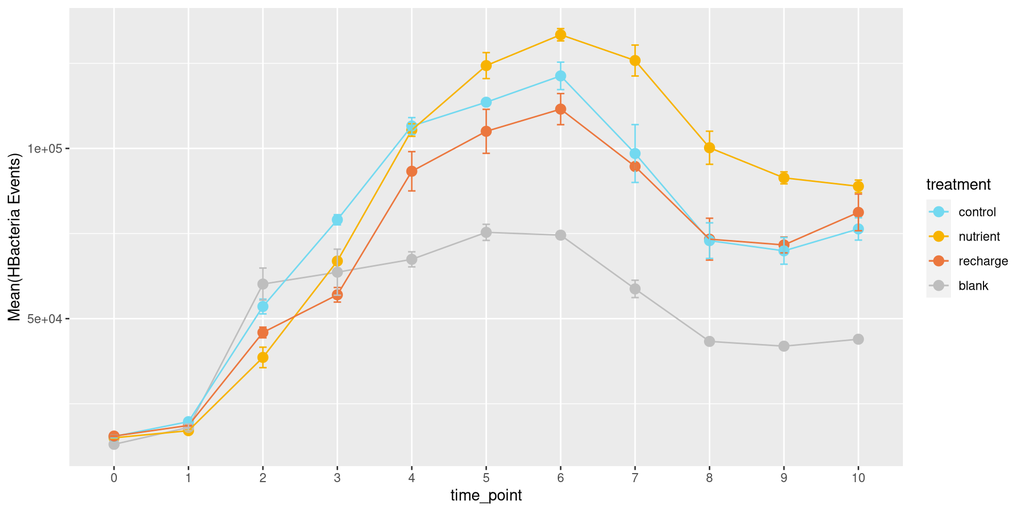

```r
# order time points
rem[ , stage := sub("remin_T","", stage)]
rem[ , stage := factor(stage, levels = 0:10)]

# mean and se
se <- function(x) sqrt(var(x) / length(x))

rem_mean = rem[ , .(mean = mean(HBacteria.Events),
                    se = se(HBacteria.Events)),
                  by = c("stage","treatment")]



# plot bacterial counts
hbac = ggplot(rem_mean, aes(x = stage,
                     y = mean,
                     color = treatment,
                     group = treatment))+
  geom_point(size =3)+
  geom_line()+
  geom_errorbar(aes(ymin = mean - se, ymax = mean + se, width = 0.1))+
  scale_color_manual(values = turnt_clrs) +
  labs(y = "Mean(HBacteria Events)",
       x = "time_point")

ggsave(plot = hbac, file = "plots/fcm/hbacteria_remin.pdf", height = 7, width = 10)

hbac
```

# Exudations

Quickly check bacterial counts following the initial and final exudations. These were done with filtered sea water, so counts should be pretty low.

Notes:

- Exudation 1 counts look a bit variable :/
- Exudation 2 counts were more stable and even across the treatments. It’s good that exudation 2 isn’t super variable, because we used those exudates as substrate for the remin.

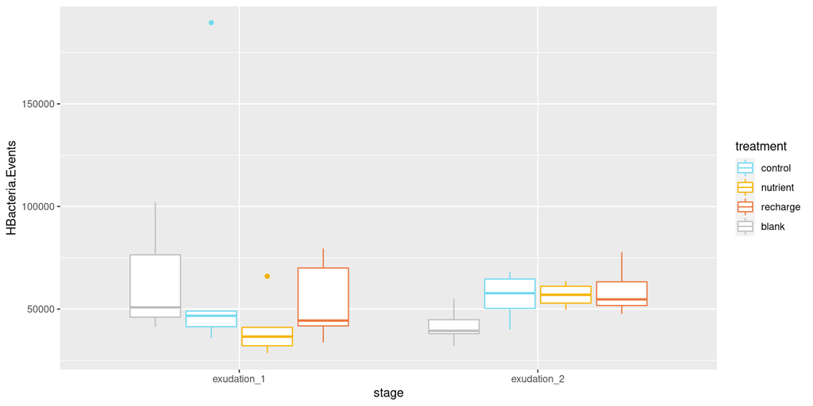

```r
ggplot(exu, aes(x = stage,
                y = HBacteria.Events,
                color = treatment))+
  geom_boxplot()+
  scale_color_manual(values = turnt_clrs)
```